# PRINCIPIOS DE DISEÑO EXPERIMENTAL: DISEÑOS DE DOS FACTORES (SELECTION PROCESSES OF EXPLANATORY VARIABLES IN STATISTICAL MODELS)

# CASO DE APLICACIÓN: EFECTO DEL RÉGIMEN ALIMENTICIO EN EL NIVEL DE PROTEÍNAS EN LA SANGRE DE LAS CHELONIA MYDAS Y KINOSTERNON SCORPIOIDE

## 1. Generalidades

Es recomendable cargar el `tortugas2.csv` y verificar que la variable **condición** sea un factor con los niveles adecuados.

```r
base=read.csv("tortugas2.csv")
base$cond=as.factor(base$cond)
levels(base$cond)=c("estricta","balanceada","abundancia")
base$especie=as.factor(base$especie)
str(base)
```

```
## 'data.frame':    24 obs. of  3 variables:
##  $ especie : Factor w/ 2 levels "chelonia","kynosternon": 1 1 1 1 1 1 1 1 1 1 ...
##  $ cond    : Factor w/ 3 levels "estricta","balanceada",..: 1 1 1 1 2 2 2 2 3 3 ...
##  $ proteina: int  32 30 34 35 40 43 43 42 38 35 ...
```

```r
attach(base)
```

Como puede observarse, los factores que se incluyen en el experimento son dos, el que se está investigando es la condición de alimento y se tiene otro factor que es la especie de tortuga.

En relación a las características de los factores y el alcance del experimento, debe decirse que el factor de diseño es la condición de alimento, pues el interés del estudio es analizar el efecto que tiene cada una de las condiciones sobre la proteína promedio que tienen las tortugas que se alimentan de cada forma. A cada tortuga se le puede asignar aleatoriamente una condición, con lo cual las diferencias que se observen se pueden vincular a la condición (régimen alimenticio) viendo en ello una relación de causa y efecto. Por otra parte, se incluye la especie porque posiblemente el comportamiento no es el mismo en ambas especies. Es importante este factor puesto que el estudio también tiene como objetivo analizar si el efecto de la condición es el mismo en cada especie, es decir, analizar la interacción.

En relación a los aspectos centrales del análisis, interesa primero ver si el efecto que tiene la condición de alimento es el mismo en ambas especies y, de ser así, debe cuantificarse ese efecto por separado en cada especie. Si el efecto es el mismo en ambas especies entonces se puede dar una conclusión general sobre el efecto que tiene cada condición en la proteína promedio sin diferenciar esta conclusión por especie.

Existe un total de 6 tratamientos en este experimento, que se obtienen de estudiar las tres condiciones para cada una de las dos especies.

## 2. Verificando el número de repeticiones por tratamiento.

```r
table(cond,especie)
```

```
##             especie
## cond         chelonia kynosternon
##   estricta          4           4
##   balanceada        4           4
##   abundancia        4           4
```

Se observa que es balanceado (todos los tratamientos son asignados a un número igual de unidades experimentales, véase http://halweb.uc3m.es/esp/Personal/personas/jmmarin/esp/Disenno/IntroDE.pdf).

## 3. Calculando la media general de la respuesta.

```r
medgen=mean(proteina)
medgen
```

```
## [1] 36
```

## 4. Efectos Simples

Pueden obtenerse los efectos simples de cada **condición**, es decir, las diferencias entre cada media de condición y la media general; esto es similar al modelo que usa $\tau$, pero dicho modelo plantea el escenario de un solo factor. Por distinción respecto a tal modelo, los valores de los efectos simples para **condición** se denotarán como $\alpha$.

```r
alfa=tapply(proteina,cond,mean)-medgen
alfa
```

```
##   estricta balanceada abundancia
##     -3.375      2.375      1.000
```

Deben estimarse también los efectos simples de cada **especie**, que se denotarán como $\beta$.

```r
beta=tapply(proteina,especie,mean)-medgen
beta
```

```
##    chelonia kynosternon
##           1          -1
```

## 5. Calculando los promedios observados de los 6 tratamientos

Es recomendable utilizar la sintaxis `tapply`, adicionándole una lista con los factores para que puedan interactuar entre sí y así obtener la media para cada combinación o tratamiento: `tapply(Y,list(X1,X2),mean)`.

```r
med=tapply(proteina,list(cond,especie),mean)
med
```

```
##            chelonia kynosternon
## estricta      32.75       32.50
## balanceada    42.00       34.75
## abundancia    36.25       37.75
```

Además, pueden obtenerse los promedios estimados bajo el modelo sin interacción. Esto puede realizarse manualmente vía el modelo sin interacción:

$$\mu_{ij}=\mu+\alpha_i+\beta_j$$

```r
mest=medgen+rep(alfa,2)+rep(beta,each=3)
mest
```

```
##   estricta balanceada abundancia   estricta balanceada abundancia
##     33.625     39.375     38.000     31.625     37.375     36.000
```

## 6. Análisis Descriptivo

Puede construirse un gráfico de los valores de **proteína** para interpretar descriptivamente si existe **interacción entre condición y especie**.

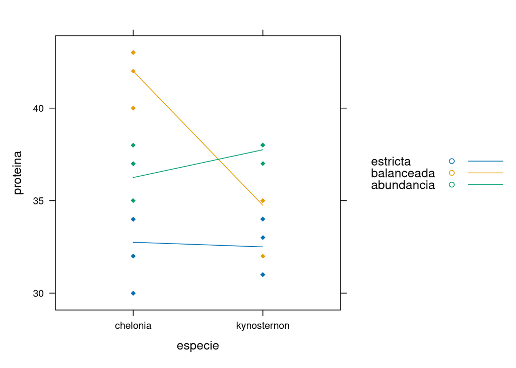

```r
library(lattice)
xyplot(proteina~especie,groups=cond,
pch=18,type=c("p","a"),auto.key=T)
```

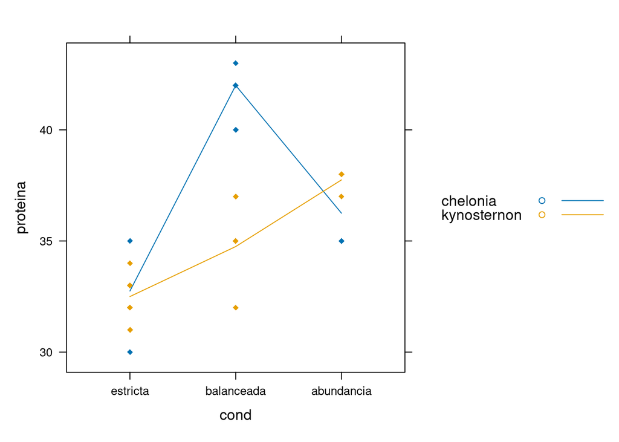

```r
xyplot(proteina~cond,groups=especie,
pch=18,type=c("p","a"),auto.key=T)
```

A causa de lo anterior, deben compararse los promedios observados con los promedios estimados y, a partir de ello, obtener la cantidad que debe sumarse o restarse a cada promedio observado para obtener una estimación que cumpla con el supuesto de NO-interacción. Estas cantidades son conocidas como *interacciones*

```r
efint=med-mest
efint
```

```
##            chelonia kynosternon
## estricta     -0.875       0.875
## balanceada    2.625      -2.625
## abundancia   -1.750       1.750
```

Estas cantidades deben restarse al promedio observado para obtener la estimación que asegura que no haya interacción. Por ejemplo, en el caso de **estricta** para chelonia se debe sumar 0.875 (porque tiene ya signo negativo), en el caso de balanceada se debería restar 2.625 (porque tiene signo positivo) y en el caso de abundancia se debería sumar 1.75 (porque tiene ya signo negativo). De esta forma los promedios distarían una cantidad idéntica a la que se obtendría en el caso correspondiente para kynosternon (lo que implica rectas paralelas). Estas cantidades se llaman *efectos de interacción*. La lógica es simple: si se probó gráficamente que existe interacción, debe usarse el modelo $\mu_{ij}=\mu+\alpha_i+\beta_j$ y, puesto que $\mu_{ij}$ es el modelo sin interacción, para obtener las $ij$ medias de nivel de proteína en sangre bajo tal escenario (descartando del análisis los efectos de interacción factorial), según el régimen alimenticio $i$ para la especie de tortuga $j$, deben restársele a la media general los efectos de interacción existentes entre los $\alpha_i$ factores (régimenes alimenticios) a distintos niveles $\beta_j$ (para cada especie). Lo anterior explica por qué las cantidades referidas antes se adicionan o sustraen en función del signo que tengan, porque el criterio es que deben sustraerse tales efectos de las $\mu_{ij}$ estimadas.

## 4. Varianzas de los Tratamientos

```r
v=tapply(proteina,list(cond,especie),var)
v
```

```
##            chelonia kynosternon
## estricta   4.916667    1.666667
## balanceada 2.000000    4.250000
## abundancia 2.250000    0.250000
```

Los tratamientos son seis porque las diferentes aplicaciones de regímenes alimenticios en las dos especies son seis, que matemáticamente se expresa como $nCr$, que significa que se aplican (matemáticamente hablando, se combinan) tres tratamientos sobre dos especies diferentes.

Debe verificarse si se cumple el supuesto de homoscedasticidad. Puede usarse la prueba de Bartlet con mediante `bartlett.test` indicando `Y~interaction(X1,X2)`.

```r
bartlett.test(proteina~interaction(cond,especie))
```

```
##
##  Bartlett test of homogeneity of variances
##
## data:  proteina by interaction(cond, especie)
## Bartlett's K-squared = 5.2091, df = 5, p-value = 0.3909
```

Ante la hipótesis de homoscedasticidad se obtiene una probabilidad asociada de 0.39, por lo que se decide no rechazar esa hipótesis, con lo cual no se tiene evidencia de heteroscedasticidad. Cuando se calcularon las varianzas en los diferentes tratamientos se ven grandes diferencias ya que la menor es 0.25 y la mayor 4.91, sin embargo, la prueba no logra demostrar formalmente que las varianzas son diferentes seguramente por la poca cantidad de réplicas en cada tratamiento (de ahí la importancia de las pruebas gráficas para muestras pequeñas, donde las pruebas formales no son fiables -debido a su misma estructura matemática, concebida bajo una visión filosófica de largo plazo-, para comparar sus resultados con los de tales pruebas formales). Para continuar el ejercicio, se continuará suponiendo que los datos provienen de poblaciones cuyas varianzas son iguales, a pesar que existe evidencia lógica de que no es así.

Adicionalmente, puede estimarse una medida de la variabilidad del error asumiendo homoscedasticidad.

```r
round(mean(v),2)
```

```
## [1] 2.56
```

## 5. Estimando los efectos simples y de interacción

Esto puede hacerse usando la sintaxis `model.tables`. Para ello, debe escribirse primero el modelo con interacción entre **condición** y **especie** con la función `aov`. Recuérdese que la interacción se agrega en un modelo de cualquiera de las siguientes formas: `Y~X1+X2+X1:X2` o `Y~X1*X2`.

```r
mod1=aov(proteina~cond*especie)
model.tables(mod1)
```

```
## Tables of effects
##
##  cond
## cond
##   estricta balanceada abundancia
##     -3.375      2.375      1.000
##
##  especie
## especie
##    chelonia kynosternon
##           1          -1
##
##  cond:especie
##             especie
## cond         chelonia kynosternon
##   estricta   -0.875    0.875
##   balanceada  2.625   -2.625
##   abundancia -1.750    1.750
```

Comparando estos últimos resultados con los obtenidos antes de ellos (estimados manualmente), se obtienen los mismos efectos simples (alpha y beta), así como los mismos efectos de interacción.

## 6. Estimación de los Contrastes

Para contrastar los efectos (en ello reside la estimación de contrastes), debe escribirse el modelo con la sintaxis `lm` (llamándolo `mod2`). Es importante tener presente que, por su configuración preestablecida, R usa el modelo de **tratamiento referencia**. Por ello, debe cambiarse al modelo de **suma nula** usando `options(contrasts=c("contr.sum","contr.poly"))`.

```r
options(contrasts=c("contr.sum","contr.poly"))
mod2=lm(proteina~cond*especie)
```

Puede observarse la matriz de estructura usando `model.matrix(mod2)` con la finalidad de identificar con qué determinaciones formales corresponde cada columna, así como también vincular los códigos de las mismas con los niveles de cada factor.

```r
contrasts(cond)
```

```
##            [,1] [,2]
## estricta      1    0
## balanceada    0    1
## abundancia   -1   -1
```

```r
contrasts(especie)
```

```
##             [,1]
## chelonia       1
## kynosternon   -1
```

```r
# "model.matrix()" es la sintaxis que sirve para presentar de forma ordenada cómo se estiman en el modelo de contrastes L cada uno de los efectos y las interacciones entre efectos
model.matrix(mod2)
```

```
##    (Intercept) cond1 cond2 especie1 cond1:especie1 cond2:especie1
## 1            1     1     0        1              1              0
## 2            1     1     0        1              1              0
## 3            1     1     0        1              1              0
## 4            1     1     0        1              1              0
## 5            1     0     1        1              0              1
## 6            1     0     1        1              0              1
## 7            1     0     1        1              0              1
## 8            1     0     1        1              0              1
## 9            1    -1    -1        1             -1             -1
## 10           1    -1    -1        1             -1             -1
## 11           1    -1    -1        1             -1             -1
## 12           1    -1    -1        1             -1             -1
## 13           1     1     0       -1             -1              0
## 14           1     1     0       -1             -1              0
```

[output cut: 18 more lines]

La matriz de estructura tiene dos columnas para condición con códigos 0, 1 y -1 y, de forma similar, una columna para especie con códigos 1 y -1. El -1 corresponde siempre al tratamiento que no se está analizando, el cual es darle comida en abundancia las kynosternon. La columna de interacción es el producto de las otras dos columnas.

Adicionalmente, deben extraerse los coeficientes para obtener los efectos simples y de interacción que no aparecen debido a la restricción de suma nula.

```r
mod2$coef
```

```
##    (Intercept)          cond1          cond2       especie1 cond1:especie1
##         36.000         -3.375          2.375          1.000         -0.875
## cond2:especie1
##          2.625
```

```r
# Se multiplica por -1 la suma de los efectos del régimen alimenticio 1 (cond1) y 2 (cond2) para obtener el efecto del régimen alimenticio 3 (cond3)
##Sin interacción entre régimen alimenticio (cond1, cond2, cond3) y especie
-(-3.375+2.375)
```

```
## [1] 1
```

```r
##Con interacción entre régimen alimenticio (cond1, cond2, cond3) y especie
-(-0.875+2.625)
```

```
## [1] -1.75
```

El efecto de la condición 1 (estricta) es -3.375, el de la condición 2 (dieta regulada) es 2.375. Aquí falta el de la condición 3 (abudancia) que se obtiene como -(-3.375+2.375)=1. El efecto de la especie 1 (chelonia) es 1 y falta la otra especie cuyo efecto es -1. El efecto de interacción para cond1-especie1 es -0.875 por lo que para cond1-especie2 es 0.875. Elefecto de interacción para cond2-especie1 es 2.625 por lo que para cond2-especie2 es -2.625. Se deben obtener los últimos con cond3-especie1: -(-0.875+2.625)=-1.75 y para cond3-especie2 1.75.

## 7. Estimación de los promedios con el modelo con interacción entre efectos

A continuación, se presenta un ejemplo de estimacion de los promedios con el modelo que tiene interacción.

```r
(Cond1Especie2= 36.00-3.375-1+0.875)
```

```
## [1] 32.5
```

```r
(Cond3Especie1= 36.00-(-3.375+2.375)+1-(-0.875+2.625))
```

```
## [1] 36.25
```

```r
(Cond3Especie2=36.00-(-3.375+2.375)-1+(-0.875+2.625))
```

```
## [1] 37.75
```

```r
(Cond2specie2=36.00+2.375-1-2.625)
```

```
## [1] 34.75
```

```r
med
```

```
##            chelonia kynosternon
## estricta      32.75       32.50
## balanceada    42.00       34.75
## abundancia    36.25       37.75
```

## 8. Estimación manual individual del nivel promedio de proteína en sangre de las chelonia bajo un régimen alimenticio estricto con coeficientes y vector de contrastes

Pueden utilizarse los coeficientes antes estimados junto con un vector de contrastes para calcular manualmente el promedio de **chelonia con estricta**, con el objetivo de compararlo con el promedio observado de ese tratamiento.

```r
coef=mod2$coef
round(coef,2)
```

```
##    (Intercept)          cond1          cond2       especie1 cond1:especie1
##          36.00          -3.37           2.37           1.00          -0.88
## cond2:especie1
##           2.63
```

```r
c(1,1,0,1,1,0)%*%coef
```

```
##       [,1]
## [1,] 32.75
```

## 9. Estimación manual del nivel promedio de proteína en sangre de las chelonia para los demás regímenes alimenticios (tratamientos)

Chelonia con dieta balanceada:

```r
c(1,0,1,1,0,1)%*%coef
```

```
##      [,1]
## [1,]   42
```

Chelonia con dieta en abundancia:

```r
c(1,-1,-1,1,-1,-1)%*%coef
```

```
##       [,1]
## [1,] 36.25
```

Kynostenron con dieta estricta

```r
c(1,1,0,-1,-1,0)%*%coef
```

```
##      [,1]
## [1,] 32.5
```

Kynostenron con balanceada

```r
c(1,0,1,-1,0,-1)%*%coef
```

```
##       [,1]
## [1,] 34.75
```

Kynostenron con abundancia

```r
c(1,-1,-1,-1,1,1)%*%coef
```

```
##       [,1]
## [1,] 37.75
```

## 10. Tabla de ANOVA para probar la hipótesis de NO-interacción entre condición y especie

```r
anova(mod2)
```

```
## Analysis of Variance Table
##
## Response: proteina
##              Df Sum Sq Mean Sq F value    Pr(>F)
## cond          2 144.25  72.125 28.2228 2.824e-06 ***
## especie       1  24.00  24.000  9.3913  0.006677 **
## cond:especie  2  85.75  42.875 16.7772 7.710e-05 ***
## Residuals    18  46.00   2.556
## ---
## Signif. codes:  0 '***' 0.001 '**' 0.01 '*' 0.05 '.' 0.1 ' ' 1
```

## 11. Planteamiento de la Hipótesis Nula

$H_0=(\alpha*\beta)_{ij}=0$

Así, el efecto de la condición de alimento o régimen alimenticio sobre el nivel promedio de proteína en sangre no depende de la especie, es decir, es el mismo en cualquiera de las dos especies.

### 12. Estimación del Cuadro Medio Residual

Puede estimarse el Cuadrado Medio Residual y compararlo con la estimación de la varianza del error obtenida en la sección 4. Interprétese de esta forma qué significa el Cuadrado Medio Residual.

```r
round(anova(mod2)[4,3],2)
```

```
## [1] 2.56
```

```r
round(mean(v),2)
```

```
## [1] 2.56
```

Este valor coincide con la media de las varianzas obtenida anteriormente y es una medida de la variabilidad de la respuesta dentro de cada tratamiento.

Si se observan los grados de libertad de cada fuente de variación puede verificarse que para el factor **condición** hay 2 grados de libertad porque hay tres condiciones (tres niveles, que son los tipos de régimen alimenticio), mientras que para el factor **especie** hay 1 grado de libertad porque son dos especies (que son los dos niveles o tipos de especie de tortuga), de lo que se desprende que los grados de libertad con la que cada fuente de variación es estimada son el número de niveles del factor menos uno. Finalmente, para la interacción entre condición y especie hay 2 grados de libertad que se obtienen del producto de los grados de libertad de cada uno de los factores.

## 13. Cuadrado Medio de Condición y Especie

```r
round(anova(mod2)[1,3],2)
```

```
## [1] 72.12
```

```r
round(anova(mod2)[2,3],2)
```

```
## [1] 24
```

El Cuadrado Medio de **Condición** es 72.13 y es una medida de la distancia entre las medias de las condiciones o regímenes alimenticios. Similarmente, el Cuadrado Medio de **Especie** es 24 y es una medida de la distancia entre las medias de las dos especies.

## 14. Estimación de los Cuadrados Medios A Partir de los Efectos Simples

```r
table(cond)
```

```
## cond
##   estricta balanceada abundancia
##          8          8          8
```

```r
sum(8*alfa^2)/2
```

```
## [1] 72.125
```

```r
table(especie)
```

```
## especie
##    chelonia kynosternon
##          12          12
```

```r
sum(12*beta^2)/1
```

```
## [1] 24
```

## 15. Estimación de la Suma de Cuadrados de Interacción A Partir de los Efectos de Interacción

```r
table(cond,especie)
```

```
##             especie
## cond         chelonia kynosternon
##   estricta          4           4
##   balanceada        4           4
##   abundancia        4           4
```

```r
sum(4*efint^2)
```

```
## [1] 85.75
```

El Cuadrado Medio de Interacción es 42.88 y mide la magnitud general del efecto de interacción. Si esta magnitud tiende a ser pequeña, se tiene un caso con poca interacción, lo cual en este caso de aplicación sería una evidencia de débil interacción entre condición y especie. En caso contrario, si esta magnitud tiende a ser grande hay más evidencia de presencia de interacción.

## 16. Conclusión de Prueba de Hipótesis con Valor F

```r
f=42.875/2.556
round(f,2)
```

```
## [1] 16.77
```

Se observa que la variabilidad de los efectos de interacción es sumamente alta con respecto a la variabilidad residual. Al ser la primera casi 17 veces la segunda, se tiene una probabilidad asociada sumamente baja ($p<0.001$), con lo cual se rechaza la hipótesis de no-interacción. Se concluye que el efecto de la condición de alimento no es el mismo cuando se trata de Chelonia mydas que en el caso de Kynosternum scorpioides.

## 17. Planteamiento Formal de los Contrastes de Comparación de Interacción Entre Especies

Puesto que se ha determinado que sí existe una interacción estadísticamente importante entre la condición y la especie, ahora es necesario investigar cómo actúan los regímenes alimenticios en cada especie. Escriba el modelo con interacción y luego escriba los contrastes adecuados para comparar las condiciones pero dentro de cada especie.

$$M_{ij}=M+\alpha_i+\beta_j+(\alpha*\beta)_{ij}$$

El primer subíndice indica la condición y el segundo la especie. Así, debe fijarse el segundo subíndice. Se crean los contrastes de tal forma que el contraste estimado sea positivo, es decir, se pone primero aquella media cuya estimación sea mayor.

Se tienen los contrastes para chelonia:

$M21-M11$ $M21-M31$ $M31-M11$

Los contrastes para kynosternon son:

$M22-M12$ $M32-M22$ $M32-M12$

## 18. Construyendo la Matriz de Contraste de Coeficientes

Para hacer el cálculo del primer contraste se deben restar los dos vectores que producen cada una de las medias del contraste:

$c(1, 0, 1, 1, 0, 1) − c(1, 1, 0, 1, 1, 0) = c(0,−1, 1, 0,−1, 1)$

Para el segundo contraste se usan: $c(1, 0, 1, 1, 0, 1) − c(1,−1,−1, 1,−1,−1) = c(0, 1, 2, 0, 1, 2)$

Los demás se obtienen de forma similar:

```r
c(1,0,1,1,0,1)-c(1,1,0,1,1,0)
```

```
## [1]  0 -1  1  0 -1  1
```

```r
c1=c(0,-1,1,0,-1,1)

c(1,0,1,1,0,1)-c(1,-1,-1,1,-1,-1)
```

```
## [1] 0 1 2 0 1 2
```

```r
c2=c(0,1,2,0,1,2)

c(1,-1,-1,1,-1,-1)-c(1,1,0,1,1,0)
```

```
## [1]  0 -2 -1  0 -2 -1
```

```r
c3=c(0,-2,-1,0,-2,-1)

c(1,0,1,-1,0,-1)-c(1,1,0,-1,-1,0)
```

```
## [1]  0 -1  1  0  1 -1
```

```r
c4=c(0,-1,1,0,1,-1)

c(1,-1,-1,-1,1,1)-c(1,0,1,-1,0,-1)
```

```
## [1]  0 -1 -2  0  1  2
```

```r
c5=c(0,-1,-2,0,1,2)

c(1,-1,-1,-1,1,1)-c(1,1,0,-1,-1,0)
```

```
## [1]  0 -2 -1  0  2  1
```

```r
c6=c(0,-2,-1,0,2,1)

cont=cbind(c1,c2,c3,c4,c5,c6)
```

## 19. Estimación de los Contrastes

- Dé una estimación de cada contraste.

```r
L=t(cont)%*%coef
row.names(L)=c("ch:bal-est","ch:bal-abu","ch:abu-est","ky:bal-est","ky:abu-bal","ky:abu-est")
L
```

```
##            [,1]
## ch:bal-est 9.25
## ch:bal-abu 5.75
## ch:abu-est 3.50
## ky:bal-est 2.25
## ky:abu-bal 3.00
## ky:abu-est 5.25
```

## 20. Estimación de la Varianza de los Contrastes

```r
var=diag(t(cont)%*%vcov(mod2)%*%cont)
round(var,2)
```

```
##   c1   c2   c3   c4   c5   c6
## 1.28 1.28 1.28 1.28 1.28 1.28
```

Las varianzas de todos los contrastes son iguales porque es un diseño balanceado.

## 21. Verificando la Significancia Estadística de los Contrastes

Deben probarse de forma simultánea las hipótesis que establecen que cada contraste es igual a cero. Puesto que los contrastes no son ortogonales, puede usarse la corrección de Bonferroni, es decir, dividir el nivel de significancia por el número de comparaciones.

```r
ee=sqrt(var)
t=L/ee
row.names(t)=row.names(L)
round(t,2)
```

```
##            [,1]
## ch:bal-est 8.18
## ch:bal-abu 5.09
## ch:abu-est 3.10
## ky:bal-est 1.99
## ky:abu-bal 2.65
## ky:abu-est 4.64
```

```r
k=6
p=pt(t,18,lower.tail = F)
row.names(p)=row.names(L)
round(p,4)
```

```
##              [,1]
## ch:bal-est 0.0000
## ch:bal-abu 0.0000
## ch:abu-est 0.0031
## ky:bal-est 0.0310
## ky:abu-bal 0.0081
## ky:abu-est 0.0001
```

```r
round(0.05/k,4)
```

```
## [1] 0.0083
```

Todas las hipótesis, con excepción de la relativa a balanceada-estricta en kynosternon (que tiene una significancia de 0.0310), por lo que se concluye que en cada especie el nivel promedio de proteína es diferente en todas las condiciones, lo que a su vez significa que todas las condiciones (tipos de régimen alimenticio) son relevantes en el estudio del fenómeno (nivel de proteína en sangre) en casi todas las especies (la excepción es la antes mencionada). Complementariamente, para kynosternon no se ha encontrado que la dieta balanceada produzca un nivel promedio de proteína más alto que la dieta estricta.

## 21. Estimando Cotas Inferiores

Deben estimarse cotas inferiores que permitan cuantificar las diferencias que son significativas.

```r
tc=qt(1-0.05/5,18)
lim=L[-4]-tc*ee[-4]
names(lim)=row.names(L)[-4]
round(lim,2)
```

```
## ch:bal-est ch:bal-abu ch:abu-est ky:abu-bal ky:abu-est
##       6.36       2.86       0.61       0.11       2.36
```

Se concluye con 95% de confianza que el nivel promedio de proteína en chelonia es al menos 6.36gr/ml mayor con dieta balanceada que con dieta estricta y al menos 2.86gr/ml mayor con dieta balanceada que con abundancia. En kynosternon abundancia aventaja a dieta estricta en al menos 2.36gr/ml. Las otras dos diferencias resultan poco relevantes, dado que para el especialista una diferencia importante es más de 1 gr/ml.